# Homework 1

## Adam Finch

```python
#import necessary packages

import pandas as pd
import numpy as np
from matplotlib import pyplot as plt
from sklearn.model_selection import train_test_split
from sklearn.compose import ColumnTransformer
from sklearn.impute import SimpleImputer
from sklearn.pipeline import Pipeline
from sklearn.preprocessing import StandardScaler, OneHotEncoder
import seaborn as sns
import warnings

warnings.filterwarnings('ignore')
%matplotlib inline
```

# Question 1: Density Plot (20 points)

```python
#First read in the csv file (I downloaded it from Kaggle and put a copy in my current directory):
df = pd.read_csv('fire_archive_V1_96617.csv')
```

```python
#Use head to show the first few observations
df.head(5)
```

|  | latitude | longitude | bright_ti4 | scan | track | acq_date | acq_time | satellite | instrument | confidence | version | bright_ti5 | frp | type |
| --- | --- | --- | --- | --- | --- | --- | --- | --- | --- | --- | --- | --- | --- | --- |
| 0 | -34.45902 | 150.88040 | 326.5 | 0.60 | 0.71 | 2019-08-01 | 246 | N | VIIRS | n | 1 | 290.7 | 5.8 | 3 |
| 1 | -31.70724 | 151.07191 | 367.0 | 0.56 | 0.69 | 2019-08-01 | 247 | N | VIIRS | h | 1 | 291.9 | 10.4 | 0 |
| 2 | -31.39626 | 149.65253 | 325.2 | 0.68 | 0.74 | 2019-08-01 | 247 | N | VIIRS | n | 1 | 292.7 | 5.6 | 0 |
| 3 | -30.39774 | 152.06432 | 347.8 | 0.48 | 0.65 | 2019-08-01 | 247 | N | VIIRS | n | 1 | 287.6 | 9.1 | 0 |
| 4 | -31.20248 | 151.89766 | 350.7 | 0.50 | 0.66 | 2019-08-01 | 247 | N | VIIRS | n | 1 | 292.3 | 9.4 | 0 |

```python
#Use shape to see how many observations and features are in my data set
df.shape
```

```
(184778, 14)
```

### 1a) - 1d) PLOTS

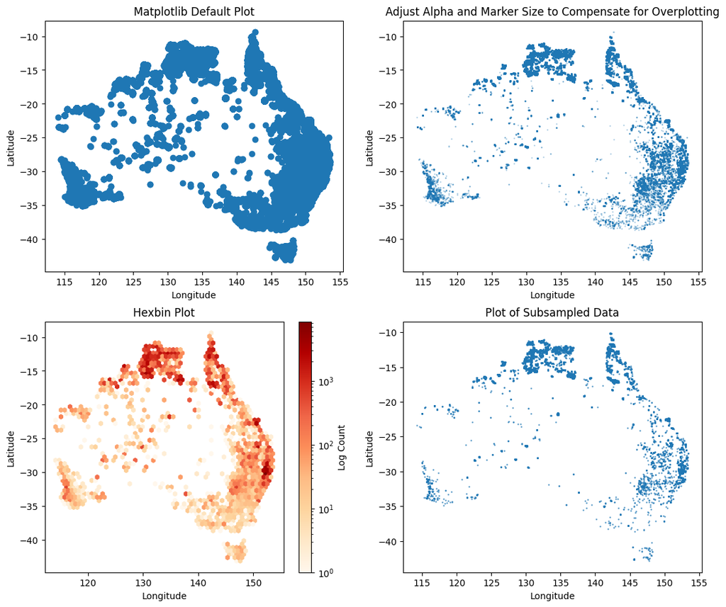

```python
x = df.longitude
y = df.latitude

plt.figure(figsize=(13,11))

# a) Using Matplotlib Defaults:

plot1 = plt.subplot(2,2,1)
plot1.scatter(x,y)
plot1.set_ylabel('Latitude')
plot1.set_xlabel('Longitude')
plot1.set_title('Matplotlib Default Plot')

# b) Adjusting alpha / marker size to compensate for overplotting

plot2 = plt.subplot(2,2,2)
plot2.scatter(x, y, s=0.5, alpha=0.3)
plot2.set_ylabel('Latitude')
plot2.set_xlabel('Longitude')
plot2.set_title('Adjust Alpha and Marker Size to Compensate for Overplotting')

# c) Using a hexbin plot
#Note: For this I chose to use the log count

plot3 = plt.subplot(2,2,3)
hexbin = plot3.hexbin(x,y, bins='log', cmap='OrRd', gridsize=60)
plot3.set_ylabel('Latitude')
plot3.set_xlabel('Longitude')
plot3.set_title('Hexbin Plot')
cbar = plt.colorbar(hexbin, ax=plot3)
cbar.set_label('Log Count')

# d) Subsampling the data set:
#There are 184,778 observations. I chose to subsample 15,000 of them for my subsampling plot
subsample = df.sample(15000, random_state = 42)
ss_x = subsample.longitude
ss_y = subsample.latitude

plot4 = plt.subplot(2,2,4)
plot4.scatter(ss_x, ss_y, s=0.75, alpha=0.6)
plot4.set_ylabel('Latitude')
plot4.set_xlabel('Longitude')
plot4.set_title('Plot of Subsampled Data')

plt.show()
```

### In what areas are most of the anomalies (measurements) located?

There appears to be a higher frequency of observations in Northern Australia, as well as Southeastern Australia. In general, the anomalies also appear to be concentrated around the coast, with far less inland measurements. This makes sense given that most of Australia's population lives in cities nearby the coast.

# Question 2: Visualizing class membership (20 points)

### Visualize the distribution of Brightness temperature I-4 as a histogram

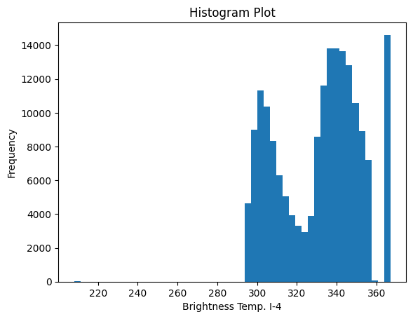

```python
histogram = plt.axes()
histogram.hist(df.bright_ti4, bins=50)
histogram.set_ylabel('Frequency')
histogram.set_xlabel('Brightness Temp. I-4')
histogram.set_title('Histogram Plot')
```

### Small multiples plot of whether the brightness is saturated

```python
print(f'Maximum Brightness Temperature I-4: {max(df.bright_ti4)}')
```

```
Maximum Brightness Temperature I-4: 367.0
```

```python
# This means that brightness is saturated when bright_ti4 = 367
# The next step is to separate the data into saturated and non saturated observations
# I do this by creating a boolean variable that is equal to 1 if an observation is saturated, and 0 otherwise.

df['sat_bright_ti4'] = (df.bright_ti4 == 367)
df['sat_bright_ti4'].value_counts()

# Now create two new data frames based upon this boolean variable:

df_sat, df_unsat = df.loc[df['sat_bright_ti4'] == True] , df.loc[df['sat_bright_ti4'] == False]

x_sat = df_sat.longitude
y_sat = df_sat.latitude
x_unsat = df_unsat.longitude
y_unsat = df_unsat.latitude
```

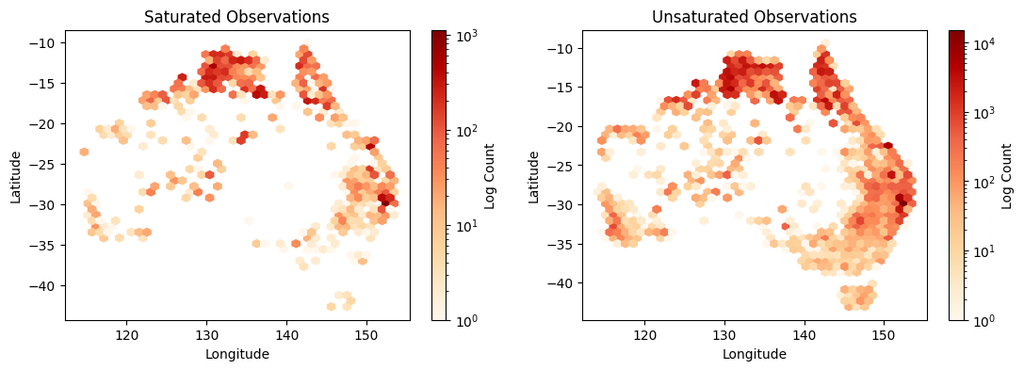

```python
#There are 14,611 saturated observations and 170,167 non-saturated observations.
#Now I can plot them side by side:

plt.figure(figsize = (13, 4))

# Saturated plot:

sat_plot = plt.subplot(1,2,1)
sat_hexbin = sat_plot.hexbin(x_sat,y_sat, bins='log', cmap='OrRd', gridsize=40)
sat_plot.set_ylabel('Latitude')
sat_plot.set_xlabel('Longitude')
sat_plot.set_title('Saturated Observations')
cbar = plt.colorbar(sat_hexbin, ax=sat_plot)
cbar.set_label('Log Count')

# Unsaturated plot

unsat_plot = plt.subplot(1,2,2)
unsat_hexbin = unsat_plot.hexbin(x_unsat, y_unsat, bins='log', cmap='OrRd', gridsize = 40)
unsat_plot.set_ylabel('Latitude')
unsat_plot.set_xlabel('Longitude')
unsat_plot.set_title('Unsaturated Observations')
cbar = plt.colorbar(unsat_hexbin, ax=unsat_plot)
cbar.set_label('Log Count')

plt.show()
```

### Can you spot any differences in the distribution?

It appears that there are a lot of unsaturated observations in the southeastern part of Australia. This is where some of Australia's bigger cities are located (The area between Sydney and Melbourne). This may suggest that some normal city lights are being picked up by the fire detecting satellites in these areas. There are also more unsaturated observations in general.

### Plot both groups in the same axes with different colors

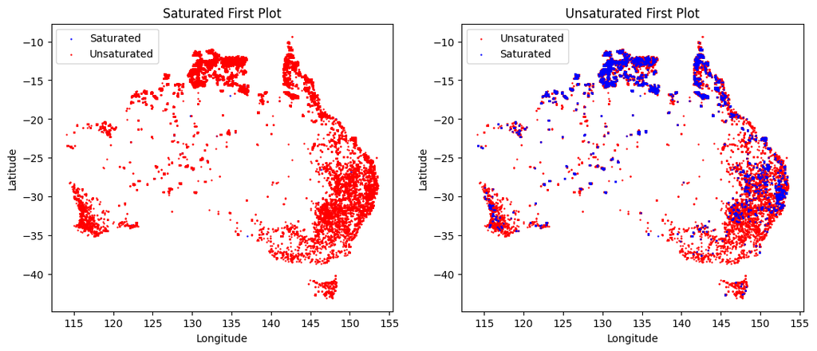

```python
plt.figure(figsize = (13,5))

# Plot with saturated first

sat_first = plt.subplot(1,2,1)
sat_first.scatter(x_sat, y_sat, c ='b', label = 'Saturated', s = 0.5)
sat_first.scatter(x_unsat, y_unsat, c = 'r', label = 'Unsaturated', s=0.5)
sat_first.set_title('Saturated First Plot')
sat_first.set_ylabel('Latitude')
sat_first.set_xlabel('Longitude')
sat_first.legend(loc='upper left')

# Plot with unsaturated first

unsat_first = plt.subplot(1,2,2)
unsat_first.scatter(x_unsat, y_unsat, c = 'r', label = 'Unsaturated', s=0.5)
unsat_first.scatter(x_sat, y_sat, c ='b', label = 'Saturated', s = 0.5)
unsat_first.set_title('Unsaturated First Plot')
unsat_first.set_ylabel('Latitude')
unsat_first.set_xlabel('Longitude')
unsat_first.legend(loc='upper left')

plt.show()
```

### Try changing the order of plotting the two classes (i.e. draw the saturated first then the non-saturated or the other way around). How does that impact the result?

Because there are so many more unsaturated data points, if you plot the saturated data points first and then plot the unsaturated data points on top of them, the saturated data is almost completely covered up (as shown by the graph on the left). Plotting the unsaturated data points first is a more accurate representation of the data because you can see both saturated and unsaturated data together on one graph (as shown on the right). However, this may still misrepresent how many saturated data points there are compared to unsaturated -- the graph on the right makes it seem as though the two groups are fairly similar in size, when in reality there is much more unsaturated data.

### Can you find a better way to compare the two distributions?

The plot on the right can be improved upon by adjusting the alpha values and changing the marker sizes / shapes.

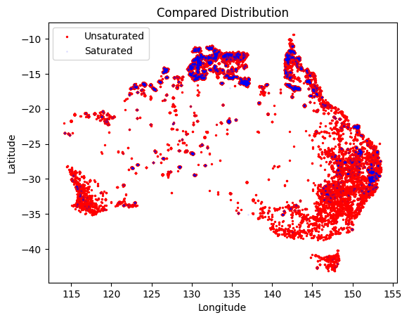

```python
compared_dist = plt.axes()
compared_dist.scatter(x_unsat, y_unsat, c = 'r', label = 'Unsaturated', s=2)
compared_dist.scatter(x_sat, y_sat, c ='b', label = 'Saturated', s = 1, alpha=0.1, marker = '*')
compared_dist.set_title('Compared Distribution')
compared_dist.set_ylabel('Latitude')
compared_dist.set_xlabel('Longitude')
compared_dist.legend(loc='upper left')
```

As shown above, placing the saturated data points on top of the unsaturated ones, but reducing the alpha value given to the saturated data points, allows us to present a more balanced representation of what the data looks like. From this visual, it is clear that there are much more unsaturated data points; however, we still see the areas where high saturation data points are more prevelent.

# Question 3: Regression Sydney Dataset (30 points)

```python
#First read in the data (I downloaded the csv from Kaggle and put it in my current directory)
df_sydney = pd.read_csv('data.csv')

#Drop the date column:
df_sydney.drop(columns='date', inplace=True)

#View the first few observations to see what the data set looks like:
df_sydney.head(5)
```

|  | price | bedrooms | bathrooms | sqft_living | sqft_lot | floors | waterfront | view | condition | sqft_above | sqft_basement | yr_built | yr_renovated | street | city | statezip | country |
| --- | --- | --- | --- | --- | --- | --- | --- | --- | --- | --- | --- | --- | --- | --- | --- | --- | --- |
| 0 | 313000.0 | 3.0 | 1.50 | 1340 | 7912 | 1.5 | 0 | 0 | 3 | 1340 | 0 | 1955 | 2005 | 18810 Densmore Ave N | Shoreline | WA 98133 | USA |
| 1 | 2384000.0 | 5.0 | 2.50 | 3650 | 9050 | 2.0 | 0 | 4 | 5 | 3370 | 280 | 1921 | 0 | 709 W Blaine St | Seattle | WA 98119 | USA |
| 2 | 342000.0 | 3.0 | 2.00 | 1930 | 11947 | 1.0 | 0 | 0 | 4 | 1930 | 0 | 1966 | 0 | 26206-26214 143rd Ave SE | Kent | WA 98042 | USA |
| 3 | 420000.0 | 3.0 | 2.25 | 2000 | 8030 | 1.0 | 0 | 0 | 4 | 1000 | 1000 | 1963 | 0 | 857 170th Pl NE | Bellevue | WA 98008 | USA |
| 4 | 550000.0 | 4.0 | 2.50 | 1940 | 10500 | 1.0 | 0 | 0 | 4 | 1140 | 800 | 1976 | 1992 | 9105 170th Ave NE | Redmond | WA 98052 | USA |

### Determine which features are continuous and which are categorical

```python
df_sydney.info()
```

```
<class 'pandas.core.frame.DataFrame'>
RangeIndex: 4600 entries, 0 to 4599
Data columns (total 17 columns):
 #   Column         Non-Null Count  Dtype
---  ------         --------------  -----
 0   price          4600 non-null   float64
 1   bedrooms       4600 non-null   float64
 2   bathrooms      4600 non-null   float64
 3   sqft_living    4600 non-null   int64
 4   sqft_lot       4600 non-null   int64
 5   floors         4600 non-null   float64
 6   waterfront     4600 non-null   int64
 7   view           4600 non-null   int64
 8   condition      4600 non-null   int64
 9   sqft_above     4600 non-null   int64
 10  sqft_basement  4600 non-null   int64
 11  yr_built       4600 non-null   int64
 12  yr_renovated   4600 non-null   int64
 13  street         4600 non-null   object
 14  city           4600 non-null   object
 15  statezip       4600 non-null   object
 16  country        4600 non-null   object
dtypes: float64(4), int64(9), object(4)
memory usage: 611.1+ KB
```

Data type "float64" is definitely continuous. Data type "object" is most likely categorical. Data type "int64" is discrete, and so further context is needed to determine whether to treat these columns as continuous or categorical.

In this case, it makes sense to treate "sqft_living", "sqft_lot", "sqft_above", and "sqft_basement" as continuous because there are many different values and these categories are clearly ordinal -- they have an established order from low square footage to high square footage. The same logic applies for "yr_built" and "yr_renovented", I will treat these as continuous for the purpose of this question.

For the categories "view", "waterfront", and "condition", I want to take a closer look at what data these columns contain:

```python
print(df_sydney["view"].value_counts(),'\n\n',df_sydney["waterfront"].value_counts(),'\n\n',df_sydney["condition"].value_counts())
```

```
view
0    4140
2     205
3     116
4      70
1      69
Name: count, dtype: int64

 waterfront
0    4567
1      33
Name: count, dtype: int64

 condition
3    2875
4    1252
5     435
2      32
1       6
Name: count, dtype: int64
```

Since "waterfront" is a boolean variable, I will put it in the categorical group.

For "view" and "condition", it looks like both of these variables are a 5-point scale. These variables can be classified as ordinal categorical variables. The higher a house scores on this scale, the more desirable the house would be in theory. However; they already have numeric values assigned to them, so there is no need to put them through an ordinal encoder. Because of this, I'm going to put them into the numeric/continuous group of variables in this case (even though they could technically be classified as categorical ordinal variables). For discrete integer types, it is important to classify them based on context in order to avoid excessive one-hot encoding.

Here is the final list of continuous and categorical variables I will use for this data set:

```python
df_cont = df_sydney[['price', 'bedrooms', 'bathrooms', 'sqft_living', 'sqft_lot', 'floors', 'view', 'condition', 'sqft_above',
                        'sqft_basement', 'yr_built', 'yr_renovated']].copy()

df_cat = df_sydney[['waterfront', 'street', 'city', 'statezip', 'country']].copy()

print('Continuous Variables: \n')
for columnName in df_cont.columns:
    if columnName == 'price':
        print('price (target var)')
    else:
        print(columnName)

print('\n Categorical Variables: \n')
for columnName in df_cat.columns:
    print(columnName)
```

```
Continuous Variables:

price (target var)
bedrooms
bathrooms
sqft_living
sqft_lot
floors
view
condition
sqft_above
sqft_basement
yr_built
yr_renovated

 Categorical Variables:

waterfront
street
city
statezip
country
```

```python
df_sydney['street'].describe()
```

```
count                      4600
unique                     4525
top       2520 Mulberry Walk NE
freq                          4
Name: street, dtype: object
```

```python
df_sydney['city'].describe()
```

```
count        4600
unique         44
top       Seattle
freq         1573
Name: city, dtype: object
```

```python
df_sydney['statezip'].describe()
```

```
count         4600
unique          77
top       WA 98103
freq           148
Name: statezip, dtype: object
```

```python
df_sydney.drop(columns='street', inplace=True)
df_cat.drop(columns='street', inplace=True)
```

### Drop rows without a valid sales price

There are no rows with a null value for price; however, there are several observations that have sales price equal to 0. I will drop those observations.

```python
df_sydney.drop(df_sydney[df_sydney['price'] == 0.0].index, inplace=True)
df_cont.drop(df_cont[df_cont['price'] == 0.0].index, inplace = True)
```

### Visualize the univariate distribution of each continuous variable, and the distribution of the target.

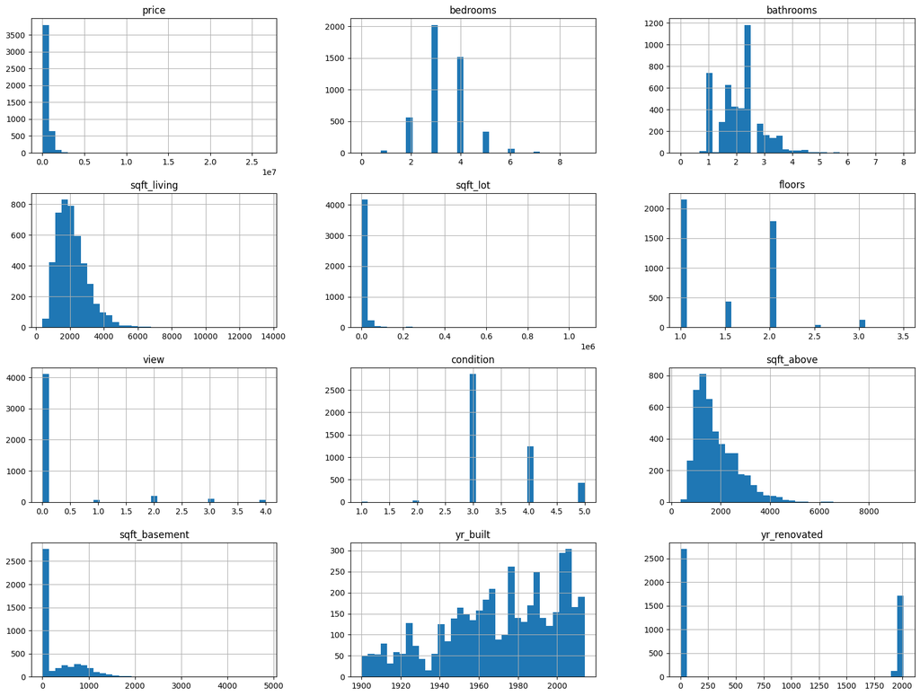

```python
df_cont.hist(bins=35, figsize=(20,15))
plt.show()
```

### Do you notice anything? Is there something that might require special treatment?

It looks like there are some outliers affecting the price distribution, causing the vast majority of the houses to be grouped into one of the bins at the beginning. There are also some variables where the majority of houses have values = 0, such as view, sqft_basement, yr_renovated, etc. This makes sense, given that most houses have never been renovated, and many houses do not have a basement. However, we may want to treat these distributions differently to see how the non-zero distribution looks for these variables. This process is shown below:

First, I want to take care of the price distribution, since it is the target variable. Here are the summary stats for price:

```python
df_sydney[["price"]].describe().apply(lambda s: s.apply('{0:.2f}'.format))
```

|  | price |
| --- | --- |
| count | 4551.00 |
| mean | 557905.90 |
| std | 563929.87 |
| min | 7800.00 |
| 25% | 326264.29 |
| 50% | 465000.00 |
| 75% | 657500.00 |
| max | 26590000.00 |

Just as I thought, the mean is significantly higher than the median, indicating outliers -- such as a 26.5 million dollar home. To remedy this, here is another histogram for 'price', while excluding any homes with prices greater than 2 million dollars.

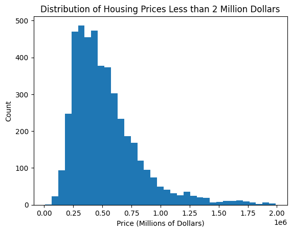

```python
price_update = plt.axes()

price_update.hist(df_sydney.query('price < 2000000')['price'], bins=35)
price_update.set_title('Distribution of Housing Prices Less than 2 Million Dollars')
price_update.set_xlabel('Price (Millions of Dollars)')
price_update.set_ylabel('Count')
plt.show()
```

Similarly, I can create new histograms for the variables yr_renovated and sqft_basement to remove values equal to zero:

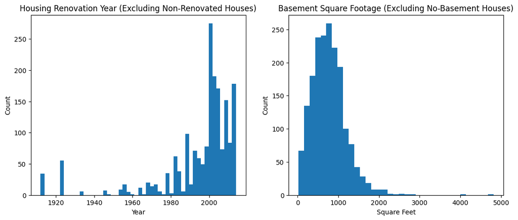

```python
plt.figure(figsize=(13,5))

#Histogram for yr_renovated:
yr_ren = plt.subplot(1,2,1)
yr_ren.hist(df_sydney.query('yr_renovated != 0')['yr_renovated'], bins=50)
yr_ren.set_title('Housing Renovation Year (Excluding Non-Renovated Houses)')
yr_ren.set_xlabel('Year')
yr_ren.set_ylabel('Count')

#Histogram for sqft_basement:
sqft_b = plt.subplot(1,2,2)
sqft_b.hist(df_sydney.query('sqft_basement != 0')['sqft_basement'], bins=35)
sqft_b.set_title('Basement Square Footage (Excluding No-Basement Houses)')
sqft_b.set_xlabel('Square Feet')
sqft_b.set_ylabel('Count')

plt.show()
```

### Visualize the dependency of the target on each continuous feature (2d scatter plot).

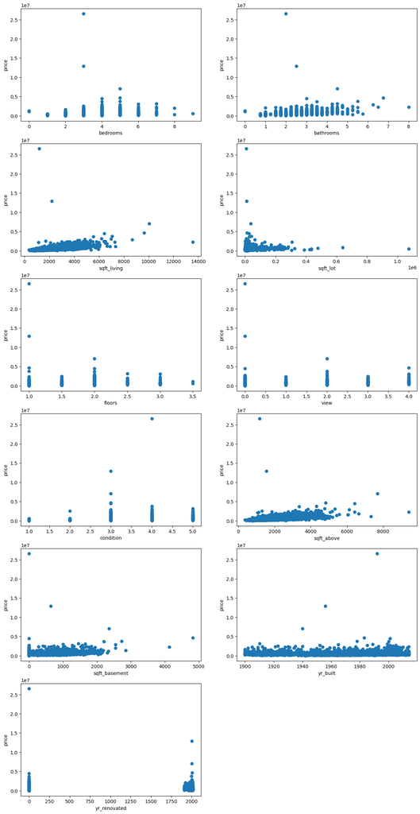

```python
cont_features = [i for i in df_cont.columns]
cont_features.remove('price')

plt.figure(figsize=(15,30))

for i, feature in enumerate(cont_features):
    plot = plt.subplot(6,2,i+1)
    plot.scatter(df_sydney[feature], df_sydney['price'])
    plot.set_xlabel(feature)
    plot.set_ylabel('price')

plt.show()
```

Once again, the high outliers in Price makes it difficult to visualize the relationship between the continuous variables and the target variable. I will plot it one more time, this time excluding any homes with a price higher than 2 million dollars.

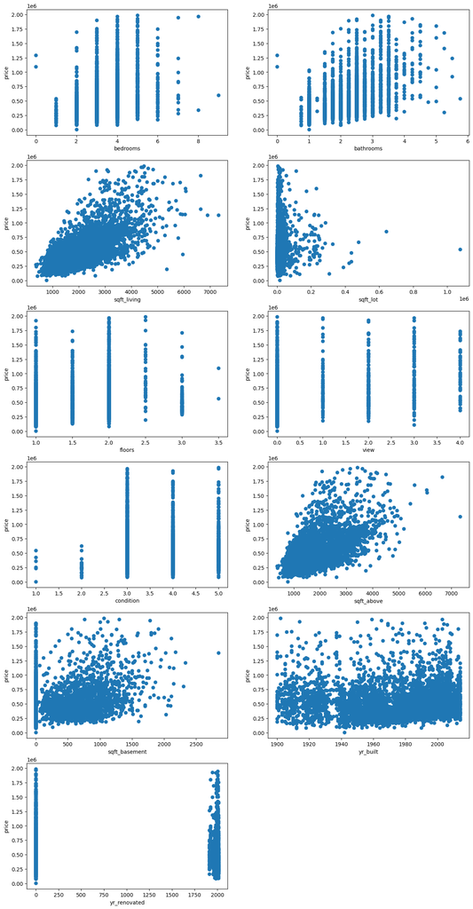

```python
plt.figure(figsize=(15,30))

for i, feature in enumerate(cont_features):
    plot = plt.subplot(6,2,i+1)
    plot.scatter(df_sydney.query('price < 2000000')[feature], df_sydney.query('price < 2000000')['price'])
    plot.set_xlabel(feature)
    plot.set_ylabel('price')

plt.show()
```

These plots are much easier to interpret, demonstrating the importance of dealing with outliers. Because I don't want these outliers to disproportionately impact my model results, I am going to drop any observations where housing price is greater than 2 million:

```python
df_sydney.drop(df_sydney[df_sydney['price'] > 2000000].index, inplace=True)
df_cont.drop(df_cont[df_cont['price'] > 2000000].index, inplace = True)
```

### Split the data into a training and testing set. Use ColumnTransformer to encode categorical variables. Impute missing values using SimpleImputer.

```python
# First, I generate a label vector y containing the target variable 'price'
y = df_sydney.filter(items=['price'])

# Next, I generate a feature matrix X containing all features except for target variable 'price'
X = df_sydney.loc[:,[i for i in df_sydney.columns if i not in ('price')]]

# Split data into training and test set:
X_train, X_test, y_train, y_test = train_test_split(X,y,random_state=42)

#Next, I'll use ColumnTransformer and SimpleImputer to create some transformers:
cat_features = [i for i in df_cat.columns]

cont_transformer = Pipeline(
    steps =[("imputer", SimpleImputer(strategy='median'))])

cont_transformer_scaled = Pipeline(
    steps =[("imputer", SimpleImputer(strategy='median')),
           ("scaler", StandardScaler())])

cat_transformer = Pipeline(
    steps =[
        ("encoder", OneHotEncoder(handle_unknown="ignore",sparse_output=False)),
        ("imputer", SimpleImputer(strategy='most_frequent'))])

#Two pipelines: one that scales the data and one that doesn't
#This will make it easier to compare how different models perform with scaled / unscaled data
ct = ColumnTransformer(
    transformers = [
        ("cont", cont_transformer, cont_features),
        ("cat", cat_transformer, cat_features),])

ct_scaled = ColumnTransformer(
        transformers = [
        ("cont", cont_transformer_scaled, cont_features),
        ("cat", cat_transformer, cat_features),])
```

### Evaluate Linear Regression (OLS), Ridge, Lasso and Elasticnet using crossvalidation with the default parameters. Does scaling the data with Standard Scaler help?

To evaluate model performance I will use root mean squared error.

#### Linear Regression (OLS):

```python
from sklearn.linear_model import LinearRegression
from sklearn.metrics import mean_squared_error as mse
from sklearn.model_selection import GridSearchCV

ols = Pipeline(
    steps = [("preprocess", ct), ("model", LinearRegression())])

param_grid = {'model__fit_intercept': [True, False], 'model__positive': [True, False]}

#Cross Validation:
grid_search = GridSearchCV(ols, param_grid, cv=5, scoring='neg_mean_squared_error')

grid_search.fit(X_train, y_train)
best_ols = grid_search.best_estimator_
y_hat = best_ols.predict(X_test)
test_mse = mse(y_test, y_hat)
test_rmse = np.sqrt(test_mse)

print(f'Testing Set RMSE without scaling: {test_rmse:.2f}')

ols_scaled = Pipeline(
    steps = [("preprocess", ct_scaled), ("model", LinearRegression())])

grid_search_scaled = GridSearchCV(ols_scaled, param_grid, cv=5, scoring='neg_mean_squared_error')
grid_search_scaled.fit(X_train, y_train)
best_ols_scaled = grid_search_scaled.best_estimator_
y_hat_scaled = best_ols_scaled.predict(X_test)
test_mse_scaled = mse(y_test, y_hat_scaled)
test_rmse_scaled = np.sqrt(test_mse_scaled)

print(f'Testing Set RMSE with Standard Scaler: {test_rmse_scaled:.2f}')
```

```
Testing Set RMSE without scaling: 134394.29
Testing Set RMSE with Standard Scaler: 131785.30
```

#### Ridge:

```python
from sklearn.linear_model import Ridge

ridge = Pipeline(
    steps = [("preprocess", ct), ("model", Ridge())])

param_grid = {'model__alpha': [0.1, 10],'model__max_iter': [100000]}

# Cross Validation of tuning parameters:
grid_search = GridSearchCV(ridge, param_grid, cv=5, scoring='neg_mean_squared_error')

grid_search.fit(X_train, y_train)
best_ridge = grid_search.best_estimator_
y_hat = best_ridge.predict(X_test)
test_mse = mse(y_test, y_hat)
test_rmse = np.sqrt(test_mse)

print(f'Testing Set RMSE without scaling: {test_rmse:.2f}')

ridge_scaled = Pipeline(
    steps = [("preprocess", ct_scaled), ("model", Ridge())])

grid_search_scaled = GridSearchCV(ridge_scaled, param_grid, cv=5, scoring='neg_mean_squared_error')
grid_search_scaled.fit(X_train, y_train)
best_ridge_scaled = grid_search_scaled.best_estimator_
y_hat_scaled = best_ridge_scaled.predict(X_test)
test_mse_scaled = mse(y_test, y_hat_scaled)
test_rmse_scaled = np.sqrt(test_mse_scaled)

print(f'Testing Set RMSE with Standard Scaler: {test_rmse_scaled:.2f}')
```

```
Testing Set RMSE without scaling: 130008.32
Testing Set RMSE with Standard Scaler: 130008.46
```

#### Lasso:

```python
from sklearn.linear_model import Lasso
lasso = Pipeline(
    steps = [("preprocess", ct), ("model", Lasso())])

param_grid = {'model__alpha': [0.01, 1],'model__max_iter': [10000]} #I limited my alpha values here because lasso takes a long time to run.
grid_search = GridSearchCV(lasso, param_grid, cv=5, scoring = 'neg_mean_squared_error')

grid_search.fit(X_train, y_train)
best_lasso = grid_search.best_estimator_
y_hat = best_lasso.predict(X_test)
test_mse = mse(y_test, y_hat)
test_rmse = np.sqrt(test_mse)

print(f'Testing Set RMSE without scaling: {test_rmse:.2f}')

lasso_scaled = Pipeline(
    steps = [("preprocess", ct_scaled), ("model", Lasso())])

grid_search_scaled = GridSearchCV(lasso_scaled, param_grid, cv=5, scoring = 'neg_mean_squared_error')
grid_search_scaled.fit(X_train, y_train)
best_lasso_scaled = grid_search_scaled.best_estimator_
y_hat_scaled = best_lasso_scaled.predict(X_test)
test_mse_scaled = mse(y_test, y_hat_scaled)
test_rmse_scaled = np.sqrt(test_mse_scaled)

print(f'Testing Set RMSE with Standard Scaler: {test_rmse_scaled:.2f}')
```

```
Testing Set RMSE without scaling: 130164.93
Testing Set RMSE with Standard Scaler: 130164.79
```

#### Elastic Net:

```python
from sklearn.linear_model import ElasticNet

elastic_net = Pipeline(
    steps = [("preprocess", ct), ("model", ElasticNet())])

param_grid = {'model__alpha': [1, 10], 'model__l1_ratio': [0.1, 0.5, 0.9], 'model__max_iter': [10000]}
grid_search = GridSearchCV(elastic_net, param_grid, cv=5, scoring='neg_mean_squared_error')

grid_search.fit(X_train, y_train)
best_elastic_net = grid_search.best_estimator_
y_hat = best_elastic_net.predict(X_test)
test_mse = mse(y_test, y_hat)
test_rmse = np.sqrt(test_mse)

print(f'Testing Set RMSE without scaling: {test_rmse:.2f}')

elastic_net_scaled = Pipeline(
    steps = [("preprocess", ct_scaled), ("model", ElasticNet())])

grid_search_scaled = GridSearchCV(elastic_net_scaled, param_grid, cv=5, scoring='neg_mean_squared_error')
grid_search_scaled.fit(X_train, y_train)
best_elastic_net_scaled = grid_search_scaled.best_estimator_
y_hat_scaled = best_elastic_net_scaled.predict(X_test)
test_mse_scaled = mse(y_test, y_hat_scaled)
test_rmse_scaled = np.sqrt(test_mse_scaled)

print(f'Testing Set RMSE with Standard Scaler: {test_rmse_scaled:.2f}')
```

```
Testing Set RMSE without scaling: 163423.16
Testing Set RMSE with Standard Scaler: 163232.49
```

### Does scaling the data with StandardScaler help?

Yes, in most cases, it does help to scale the data. This is evidenced by the lower RMSE's for the scaled data in most of the models. The one exception was the Ridge model, although the scaled and non-scaled result for Ridge turned out to be nearly identical. The model with the worst performance was Elastic Net, and the model with the best performance was Ridge. However, none of the models are performing exceptionally well. To improve performance further, it might be a good idea to dig a bit deeper into the preprocessing part of the process. For example, I could go back and drop irrelevant variables, and think about encoding my categorical variables differently (perhaps use an ordinal encoder instead of one hot encode).

# Question 4: Classification on the ’credit-g’ dataset (30 points)

```python
from sklearn.datasets import fetch_openml

credit_data = fetch_openml('credit-g', version='active')
df = pd.DataFrame(credit_data.data, columns=credit_data.feature_names)
df['class'] = credit_data.target
```

### Determine which features are continuous and which are categorical

```python
df.info()
```

```
<class 'pandas.core.frame.DataFrame'>
RangeIndex: 1000 entries, 0 to 999
Data columns (total 21 columns):
 #   Column                  Non-Null Count  Dtype
---  ------                  --------------  -----
 0   checking_status         1000 non-null   category
 1   duration                1000 non-null   float64
 2   credit_history          1000 non-null   category
 3   purpose                 1000 non-null   category
 4   credit_amount           1000 non-null   float64
 5   savings_status          1000 non-null   category
 6   employment              1000 non-null   category
 7   installment_commitment  1000 non-null   float64
 8   personal_status         1000 non-null   category
 9   other_parties           1000 non-null   category
 10  residence_since         1000 non-null   float64
 11  property_magnitude      1000 non-null   category
 12  age                     1000 non-null   float64
 13  other_payment_plans     1000 non-null   category
 14  housing                 1000 non-null   category
 15  existing_credits        1000 non-null   float64
 16  job                     1000 non-null   category
 17  num_dependents          1000 non-null   float64
 18  own_telephone           1000 non-null   category
 19  foreign_worker          1000 non-null   category
 20  class                   1000 non-null   category
dtypes: category(14), float64(7)
memory usage: 71.0 KB
```

```python
cat_vars = []
cont_vars = []

for column in df.columns:
    if df[column].dtype == 'category':
        cat_vars.append(column)
    else:
        cont_vars.append(column)

#Remove the target var:
cat_vars.remove('class')

print('Categorical Variables:')
for i in cat_vars:
    print(i)

print('\nContinuous Variables:')
for j in cont_vars:
    print(j)
```

```
Categorical Variables:
checking_status
credit_history
purpose
savings_status
employment
personal_status
other_parties
property_magnitude
other_payment_plans
housing
job
own_telephone
foreign_worker

Continuous Variables:
duration
credit_amount
installment_commitment
residence_since
age
existing_credits
num_dependents
```

### Visualize the univariate distribution of each continuous variable, and the distribution of the target.

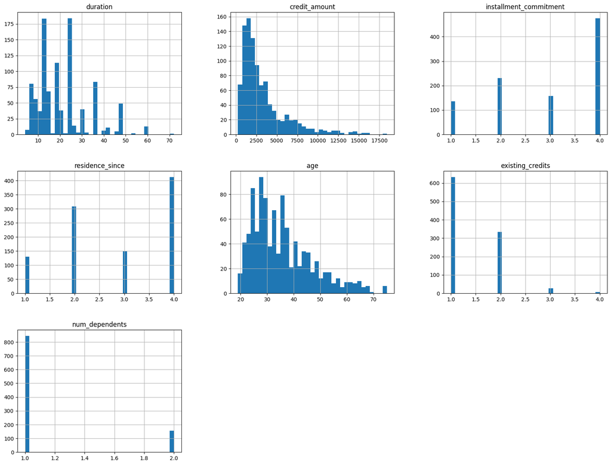

```python
df_cont = df.loc[:,[i for i in cont_vars]]
df_cont.hist(bins=35, figsize=(20,15))
plt.show()
```

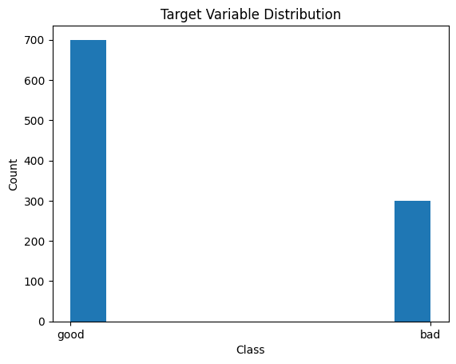

```python
target_dist = plt.axes()
target_dist.hist(df.loc[:,'class'])
target_dist.set_title('Target Variable Distribution')
target_dist.set_xlabel('Class')
target_dist.set_ylabel('Count')

plt.show()
```

### Split the data into a training and testing set.

```python
X = df.loc[:, [i for i in df.columns if i not in 'class']]
y = df.filter(items=['class'])

X_train, X_test, y_train, y_test = train_test_split(X,y,random_state = 42)

print("X_train shape:", X_train.shape)
print("y_train shape:", y_train.shape)

print("Missing values in X_train:", X_train.isnull().sum().sum())

print(cont_vars, cat_vars)
```

[output not shown]

### Preprocess the data (such as treatment of categorical variables / use ColumnTransformer to encode categorical variables)

```python
cont_transformer = Pipeline(
    steps=[("imputer", SimpleImputer(strategy='median')),
           ])

cont_transformer_scaled = Pipeline(
    steps=[("imputer", SimpleImputer(strategy='median')),
           ("scaler", StandardScaler())])

cat_transformer = Pipeline(
    steps=[
        ("onehot", OneHotEncoder(handle_unknown="ignore")),
        ("imputer", SimpleImputer(strategy='most_frequent'))
    ]
)

# The first column transformer does not include scaling, the second transformer does.
# This will allow me to easily calculate the difference in model performance using scaled and non scaled data.
ct = ColumnTransformer(
    transformers = [
        ("cont", cont_transformer, cont_vars),
        ("cat", cat_transformer, cat_vars)])

ct_scaled = ColumnTransformer(
    transformers = [
        ("cont_scaled", cont_transformer_scaled, cont_vars),
        ("cat", cat_transformer, cat_vars)])
```

### Evaluate Logistic Regression, Linear Support Vector Machines and nearest neighbors.

#### Logistic Regression

```python
from sklearn.linear_model import LogisticRegression
from sklearn.metrics import precision_score, recall_score

# Evaluate model without scaling:
logreg = Pipeline(
    steps = [("preprocess", ct), ("classifier", LogisticRegression())])

logreg.fit(X_train, y_train)
y_hat = logreg.predict(X_test)
precision = precision_score(y_test, y_hat, pos_label = 'good')
recall = recall_score(y_test, y_hat, pos_label='good')
print("Test Set Accuracy Without Scaling: %.3f" % logreg.score(X_test, y_test))
print("Test Set Precision Without Scaling: %.3f" % precision)
print("Test Set Recall Without Scaling: %.3f" % recall)

# With scaling:
logreg_scaled = Pipeline(
    steps = [("preprocess", ct_scaled), ("classifier", LogisticRegression())])

logreg_scaled.fit(X_train, y_train)
y_hat_scaled = logreg_scaled.predict(X_test)
precision_scaled = precision_score(y_test, y_hat_scaled, pos_label = 'good')
recall_scaled = recall_score(y_test, y_hat_scaled, pos_label='good')
print("\nTest Set Accuracy After Scaling: %.3f" % logreg_scaled.score(X_test, y_test))
print("Test Set Precision After Scaling: %.3f" % precision_scaled)
print("Test Set Recall After Scaling: %.3f" % recall_scaled)
```

```
Test Set Accuracy Without Scaling: 0.752
Test Set Precision Without Scaling: 0.796
Test Set Recall Without Scaling: 0.876

Test Set Accuracy After Scaling: 0.768
Test Set Precision After Scaling: 0.812
Test Set Recall After Scaling: 0.876
```

#### Linear Support Vector Machine

```python
from sklearn.svm import LinearSVC

svm = Pipeline(
    steps = [("preprocess", ct), ("classifier", LinearSVC())])

svm.fit(X_train, y_train)
y_hat = svm.predict(X_test)
precision = precision_score(y_test, y_hat, pos_label = 'good')
recall = recall_score(y_test, y_hat, pos_label='good')
print("Test Set Accuracy Without Scaling: %.3f" % svm.score(X_test, y_test))
print("Test Set Precision Without Scaling: %.3f" % precision)
print("Test Set Recall Without Scaling: %.3f" % recall)

svm_scaled = Pipeline(
    steps = [("preprocess", ct_scaled), ("classifier", LinearSVC())])

svm_scaled.fit(X_train, y_train)
y_hat_scaled = svm_scaled.predict(X_test)
precision_scaled = precision_score(y_test, y_hat_scaled, pos_label = 'good')
recall_scaled = recall_score(y_test, y_hat_scaled, pos_label='good')
print("\nTest Set Accuracy After Scaling: %.3f" % svm_scaled.score(X_test, y_test))
print("Test Set Precision After Scaling: %.3f" % precision_scaled)
print("Test Set Recall After Scaling: %.3f" % recall_scaled)
```

```
Test Set Accuracy Without Scaling: 0.716
Test Set Precision Without Scaling: 0.717
Test Set Recall Without Scaling: 0.994

Test Set Accuracy After Scaling: 0.768
Test Set Precision After Scaling: 0.809
Test Set Recall After Scaling: 0.882
```

#### K Nearest Neighbors

```python
from sklearn.neighbors import KNeighborsClassifier

knn = Pipeline(
    steps = [("preprocess", ct), ("classifier", KNeighborsClassifier())])

knn.fit(X_train, y_train)
y_hat = knn.predict(X_test)
precision = precision_score(y_test, y_hat, pos_label = 'good')
recall = recall_score(y_test, y_hat, pos_label='good')
print("Test Set Accuracy Without Scaling: %.3f" % knn.score(X_test, y_test))
print("Test Set Precision Without Scaling: %.3f" % precision)
print("Test Set Recall Without Scaling: %.3f" % recall)

knn_scaled = Pipeline(
    steps = [("preprocess", ct_scaled), ("classifier", KNeighborsClassifier())])

knn_scaled.fit(X_train, y_train)
y_hat_scaled = knn_scaled.predict(X_test)
precision_scaled = precision_score(y_test, y_hat_scaled, pos_label = 'good')
recall_scaled = recall_score(y_test, y_hat_scaled, pos_label='good')
print("\nTest Set Accuracy After Scaling: %.3f" % knn_scaled.score(X_test, y_test))
print("Test Set Precision After Scaling: %.3f" % precision_scaled)
print("Test Set Recall After Scaling: %.3f" % recall_scaled)
```

```
Test Set Accuracy Without Scaling: 0.664
Test Set Precision Without Scaling: 0.726
Test Set Recall Without Scaling: 0.848

Test Set Accuracy After Scaling: 0.764
Test Set Precision After Scaling: 0.787
Test Set Recall After Scaling: 0.916
```

### How different are the results? How does scaling the continuous features with StandardScaler influence the results?

Between models, the results were different prior to applying StandardScaler; however, after applying StandardScaler each model reached a very similar score (about 76.8% accuracy). All of the models showed performance improvement after applying StandardScaler. These scores were achieved using the default tuning parameters for these models. Performance could be further enhanced by performing cross validation on these tuning parameters.